# Clustered heatmap of Cryptococcus FLC1 RNAseq

Edward Wallace

2022-11-22

# Summary

Clustered heatmap of Cryptococcus FLC1 RNAseq

This analysis does:

- Heatmap per condition, of log2 fold-change

It concludes that the biggest difference in average log2-fold-change across samples is between wild-type (especially at 30°C) and flc1∆ (especially at 37°C). This supports conclusions of the PCA.

## Load count data from shared script load_count_data.Rmd

# Load and organise count data

`load_count_data.Rmd` is just to load and organise the raw count data in R, as well as loading libraries for data analysis. Other scripts can just run this one instead of duplicating code, especially scripts for differential gene expression analysis.

This runs *after* `QC_PCA.Rmd`, which does the organisation. This just loads the organised counts from the file `results/summaries/counts_bysamplecode.txt`.

## Load the organised counts

```r
counts_all <-
  here::here("results", "summaries", "counts_bysamplecode.txt") %>%
  readr::read_tsv(comment = "#",
                  col_types = "ciiiiiiiiiiiiiiiiiiiiiiiiiiiiiii")   %>%
  magrittr::set_rownames(.$Gene)
counts_all
```

```
## # A tibble: 6,795 × 32
##    Gene       Length WT_30_Y_1 WT_30_Y_2 WT_30_Y_3 FL_30_Y_1 FL_30_Y_2 FL_30_Y_3
##  * <chr>       <int>     <int>     <int>     <int>     <int>     <int>     <int>
##  1 CNAG_00002   1027       322       378       346       310       309       174
##  2 CNAG_00003   2397        19        43        27        54        52        33
##  3 CNAG_00004   3424        94        80        83       102        94        65
##  4 CNAG_00005   2162       462       399       385       378       344       310
##  5 CNAG_00006   1450      1019      1533      1256      1505      1359       778
##  6 CNAG_00007   2294       471       703       579       476       407       284
##  7 CNAG_00008   4351       141       226       206       272       259       164
##  8 CNAG_00009   1794       160       162       187       323       250       171
##  9 CNAG_00010   3879       195       199       242       362       272       159
## 10 CNAG_00011   2037        85       117       114       162       139        81
## # ℹ 6,785 more rows
## # ℹ 24 more variables: WT_37_Y_1 <int>, WT_37_Y_2 <int>, WT_37_Y_3 <int>,
## #   FL_37_Y_1 <int>, FL_37_Y_2 <int>, FL_37_Y_3 <int>, WT_37_C_1 <int>,
## #   WT_37_C_2 <int>, WT_37_C_3 <int>, FL_37_C_1 <int>, FL_37_C_2 <int>,
## #   FL_37_C_3 <int>, WT_37_E_1 <int>, WT_37_E_2 <int>, WT_37_E_3 <int>,
## #   FL_37_E_1 <int>, FL_37_E_2 <int>, FL_37_E_3 <int>, WT_37_CE_1 <int>,
## #   WT_37_CE_2 <int>, WT_37_CE_3 <int>, FL_37_CE_1 <int>, FL_37_CE_2 <int>, …
```

## Load the sample sheet

```r
sample_sheet <-
  here::here("input", "experiment",
             "CryptoRNAseqFLC1SampleKey.csv") %>%
  readr::read_csv(comment = "#", col_types = "ccccccc") %>%
  dplyr::mutate(Condition = stringr::str_sub(SampleName,start = 1L, end = -3L)) %>%
  dplyr::transmute(SampleID = as_factor(SampleID),
                   SampleName = as_factor(SampleName),
                   Condition = as_factor(Condition),
                   FLC1 = factor(FLC1, levels = c("delta", "WT")),
                   Temperature = factor(Temperature, levels = c("30", "37")),
                   Media = as_factor(Media),
                   BioRep = as_factor(BioRep))

sample_sheet
```

```
## # A tibble: 30 × 7
##    SampleID SampleName Condition FLC1  Temperature Media BioRep
##    <fct>    <fct>      <fct>     <fct> <fct>       <fct> <fct>
##  1 1        WT_30_Y_1  WT_30_Y   WT    30          YPD   1
##  2 2        WT_30_Y_2  WT_30_Y   WT    30          YPD   2
##  3 3        WT_30_Y_3  WT_30_Y   WT    30          YPD   3
##  4 4        FL_30_Y_1  FL_30_Y   delta 30          YPD   1
##  5 5        FL_30_Y_2  FL_30_Y   delta 30          YPD   2
##  6 6        FL_30_Y_3  FL_30_Y   delta 30          YPD   3
##  7 7        WT_37_Y_1  WT_37_Y   WT    37          YPD   1
##  8 8        WT_37_Y_2  WT_37_Y   WT    37          YPD   2
##  9 9        WT_37_Y_3  WT_37_Y   WT    37          YPD   3
## 10 10       FL_37_Y_1  FL_37_Y   delta 37          YPD   1
## # ℹ 20 more rows
```

## Load H99 Gene information

```r
gene_info_df <-
  here::here("input", "annotation",
             "H99_geneinfo_FungiDB59.txt") %>%
  readr::read_tsv(comment = "#")  %>%
  dplyr::rename(gene = GeneID, geneName = GeneName)
```

```r
library(ggdendro)
library(vegan)
```

# Calculate read count statistics by gene

## Check distribution of counts and baseMean

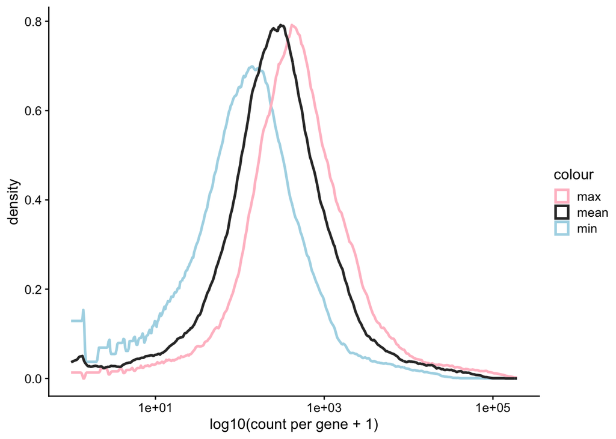

```r
count_stats_bygene <-
  counts_all %>%
  dplyr::select(-Gene, -Length) %>%
  as.matrix() %>%
  tibble(gene = rownames(counts_all),
         count_min = rowMins(.),
         count_mean = rowMeans(.),
         count_max = rowMaxs(.)) %>%
  select( - ".") # removes pipe behaviour leading to inclusion of "."

genelist_mincount_10 <-
  count_stats_bygene %>%
  filter(count_min >= 10) %>%
  pull(gene)

ggplot(data = count_stats_bygene) +
  geom_density(aes(x=count_min + 1, colour = "min"),
               size = 1, kernel = "rectangular") +
  geom_density(aes(x=count_max + 1, colour = "max"),
               size = 1, kernel = "rectangular") +
  geom_density(aes(x=count_mean + 1, colour = "mean"),
               size = 1, kernel = "rectangular") +
  scale_colour_manual(values = c("min" = "lightblue",
                                 "mean" = "grey20",
                                 "max" = "pink")) +
  scale_x_log10("log10(count per gene + 1)")
```

# DESeq on all data.

```r
dds_all <- DESeqDataSetFromMatrix(
  countData = counts_all %>%
    dplyr::select(sample_sheet$SampleName) %>%
    magrittr::set_rownames(counts_all$Gene),
  colData = sample_sheet,
  design = ~ Condition - 1 ) %>%
  DESeq()
dds_all
```

```
## class: DESeqDataSet
## dim: 6795 30
## metadata(1): version
## assays(4): counts mu H cooks
## rownames(6795): CNAG_00002 CNAG_00003 ... CNAG_14001 CNAG_14002
## rowData names(54): baseMean baseVar ... deviance maxCooks
## colnames(30): WT_30_Y_1 WT_30_Y_2 ... FL_37_CE_2 FL_37_CE_3
## colData names(8): SampleID SampleName ... BioRep sizeFactor
```

```r
resultsNames(dds_all)
```

```
##  [1] "ConditionWT_30_Y"  "ConditionFL_30_Y"  "ConditionWT_37_Y"
##  [4] "ConditionFL_37_Y"  "ConditionWT_37_C"  "ConditionFL_37_C"
##  [7] "ConditionWT_37_E"  "ConditionFL_37_E"  "ConditionWT_37_CE"
## [10] "ConditionFL_37_CE"
```

```r
results(dds_all)
```

```
## log2 fold change (MLE): Condition FL_37_CE vs WT_30_Y
## Wald test p-value: Condition FL_37_CE vs WT_30_Y
## DataFrame with 6795 rows and 6 columns
##             baseMean log2FoldChange     lfcSE      stat      pvalue        padj
##            <numeric>      <numeric> <numeric> <numeric>   <numeric>   <numeric>
## CNAG_00002  368.6172     -0.6213042 0.1159080 -5.360320 8.30746e-08 1.87973e-07
## CNAG_00003   43.9718      0.3546293 0.2660089  1.333148 1.82483e-01 2.18502e-01
## CNAG_00004   99.2921     -0.0404817 0.1733600 -0.233513 8.15363e-01 8.43007e-01
## CNAG_00005  547.3713     -0.1915087 0.1457096 -1.314318 1.88739e-01 2.25167e-01
## CNAG_00006 1427.8761     -0.2386258 0.0822359 -2.901721 3.71119e-03 5.57956e-03
## ...              ...            ...       ...       ...         ...         ...
## CNAG_08027 280.81327      0.7592693  0.133298   5.69603 1.22629e-08 2.92014e-08
## CNAG_08028  94.28386      0.4948284  0.193946   2.55138 1.07298e-02 1.52575e-02
## CNAG_08029  81.66569     -0.6419996  0.187675  -3.42081 6.24353e-04 1.01828e-03
## CNAG_14001 367.11544     -0.0314298  0.127867  -0.24580 8.05837e-01 8.35198e-01
## CNAG_14002   1.97841      3.1045255  1.386006   2.23991 2.50969e-02 3.42001e-02
```

## Select Condition-dependent log2FC at each timepoint

```r
# Create a tidy data frame that contains only the GAT201-dependent log2FC
# in a helpful format for plotting
deseq_df_Condition <-
  biobroom::tidy.DESeqDataSet(dds_all) %>%
  dplyr::mutate(Condition = term %>%
           stringr::str_remove("Condition") %>%
           factor(levels = levels(sample_sheet$Condition))) %>%
  dplyr::select(Condition, gene, baseMean, log2estimate = estimate) %>%
  dplyr::group_by(gene) %>%
  dplyr::mutate(log2FC = log2estimate - mean(log2estimate)) %>%
  dplyr::ungroup()
# restrict to genes with mincount 10
deseq_df_Condition_mincount_10 <-
  deseq_df_Condition %>%
  filter(gene %in% genelist_mincount_10)

# check we retained all the levels
unique(deseq_df_Condition$Condition)
```

```
##  [1] FL_30_Y  FL_37_C  FL_37_CE FL_37_E  FL_37_Y  WT_30_Y  WT_37_C  WT_37_CE
##  [9] WT_37_E  WT_37_Y
## 10 Levels: WT_30_Y FL_30_Y WT_37_Y FL_37_Y WT_37_C FL_37_C WT_37_E ... FL_37_CE
```

## Calculate gene expression hierarchical clusters

Here we restrict to genes with at least 10 counts in each sample. This list was calculated earlier as `genelist_mincount_10`.

This avoids a problem with numeric errors in calculations for all genes, that probably came from genes with low/zero counts.

```r
log2FC_Condition_m10_wide <-
  deseq_df_Condition_mincount_10  %>%
  select(gene, Condition, log2FC) %>%
  pivot_wider(id_cols = gene, names_from = Condition, values_from = log2FC)

preferred_gene_ordering <-
  log2FC_Condition_m10_wide %>%
  dplyr::pull(WT_30_Y)

# Function to allow calculation of distance by correlation
# not exactly as euclidean distance
distcort <- function(x) {
  as.dist(1 - cor(t(x)))
}

hclust_log2FC <-
  log2FC_Condition_m10_wide %>%
  dplyr::select(-gene) %>%
  as.matrix() %>%
  magrittr::set_rownames(log2FC_Condition_m10_wide$gene) %>%
  # head(n= 100) %>%
  # dist() %>%
  distcort() %>%
  hclust(method = "average") %>%
  reorder(wts = preferred_gene_ordering)
```

## Plot clustering dendrogram by itself

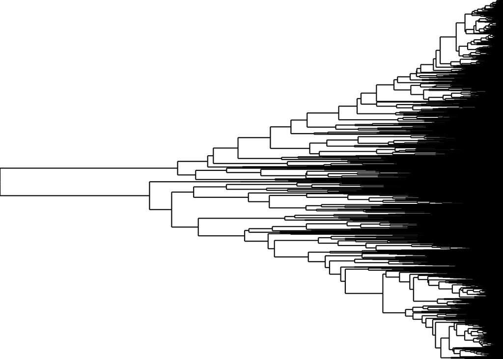

```r
# dendrogram data
hclust_log2FC_dendrodf <-
  hclust_log2FC %>% dendro_data()


plot_dendrogram_log2FC_m10 <-
  ggplot(data = hclust_log2FC_dendrodf$segments) +
  geom_segment(aes(x = x, xend = xend, y = y, yend = yend)) +
  # geom_label(data = hclust_log2FC_dendrodf$labels %>%
  #              filter(label %in% c("CNAG_06963", "CNAG_03143")),
  #            aes(x = x, y = y, label = label)) +
  theme_void() +
  scale_y_reverse() +
  coord_flip(expand = FALSE, clip = "off")
plot_dendrogram_log2FC_m10
```

## Plot the log2 fold-change in same order as clustering dendrogram

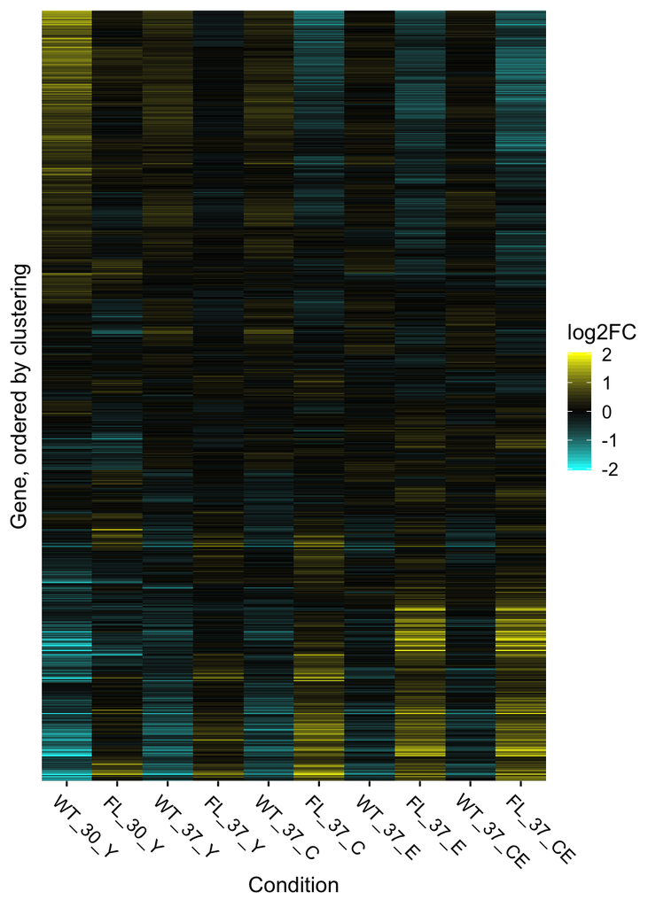

```r
deseq_df_Condition_mincount_10_dorder <-
  deseq_df_Condition_mincount_10 %>%
  mutate(gene_dorder =
           factor(gene,
                  levels = log2FC_Condition_m10_wide$gene[hclust_log2FC$order],
                  ordered = TRUE)
         )

plot_log2FC_m10_dorder <-
  ggplot(data = deseq_df_Condition_mincount_10_dorder,
         aes(x = Condition, fill = log2FC, y = gene_dorder)) +
  geom_tile() +
  scale_fill_gradient2(low = "cyan", mid = "black", high = "yellow",
                       limits = c(-2, 2), oob = scales::squish,
                       guide = guide_colorbar(nbin = 36, raster = FALSE)) +
  coord_cartesian(expand = FALSE, clip = "off") +
  theme(axis.text.x = element_text(angle = -45, hjust = 0.1),
        panel.grid.major = element_blank(),
        axis.line = element_blank(),
        axis.text.y = element_blank(), axis.ticks.y = element_blank()) +
  labs(x = "Condition",
       y = "Gene, ordered by clustering")
plot_log2FC_m10_dorder
```

```r
# ggsave(filename = "../results/clustered_heatmap_CryptoWakeupMediumTemperatureTime_tall.pdf",
#       plot_log2FC_m1_dorder + theme(axis.text.y = element_text(size = 2)),
#       width = 6, height = 72, limitsize = FALSE)
```

The next code chunk selects individual genes to highlight, so we can see where they are on the heatmap. Commenting out for now but could be useful later.

```r
genes_translation <- c(RPS3 = "CNAG_00116",
                       RPL2 = "CNAG_05232",
                       TEF1 = "CNAG_06125")
genes_stationary <- c(CQS1 = "CNAG_03012",
                      HSP12 = "CNAG_03143",
                      BLP2 = "CNAG_06347")
genes_heat <- c(SSA1 = "CNAG_06443",
                HSP90 = "CNAG_06150",
                # HSP10 = "CNAG_03892"
                TSA3 = "CNAG_06917")
genes_GAT201 <- c(GAT201 = "CNAG_01551",
                  GAT204 = "CNAG_06762",
                  LIV3 = "CNAG_05835")

genes_select <- c(genes_translation, genes_stationary,
                  genes_heat, genes_GAT201)

ggplot(data = deseq_df_MTT_mincount_1_dorder %>%
         dplyr::filter(gene %in% genes_select),
       aes(x = MediumTempTime, fill = log2FC, y = gene_dorder)) +
  geom_tile() +
  scale_fill_gradient2(low = "cyan", mid = "black", high = "yellow",
                       limits = c(-3, 3), oob = scales::squish) +
  scale_y_discrete(breaks = genes_select, labels = names(genes_select)) +
  coord_cartesian(expand = c(0,0), clip = "off") +
  theme(axis.text.x = element_text(angle = -45, hjust = 0.1),
        panel.grid.major = element_blank())

# plot_log2FC_m1_dorder +
#   geom_text(deseq_df_MTT_mincount_1_dorder %>%
#          dplyr::filter(gene %in% genes_select,
#                        MediumTempTime == "YPD_25C_0"),
#          mapping = aes(x=0, y = gene_dorder, label = str_remove(gene, "CNAG_0")),
#          size = 2, colour = "red")
```

# Combined plot of dendrogram and heatmap

This combines the previous plot panels into a single plot, showing the dendrogram aligned with the clustered heatmap, and with nice x-axis labels.

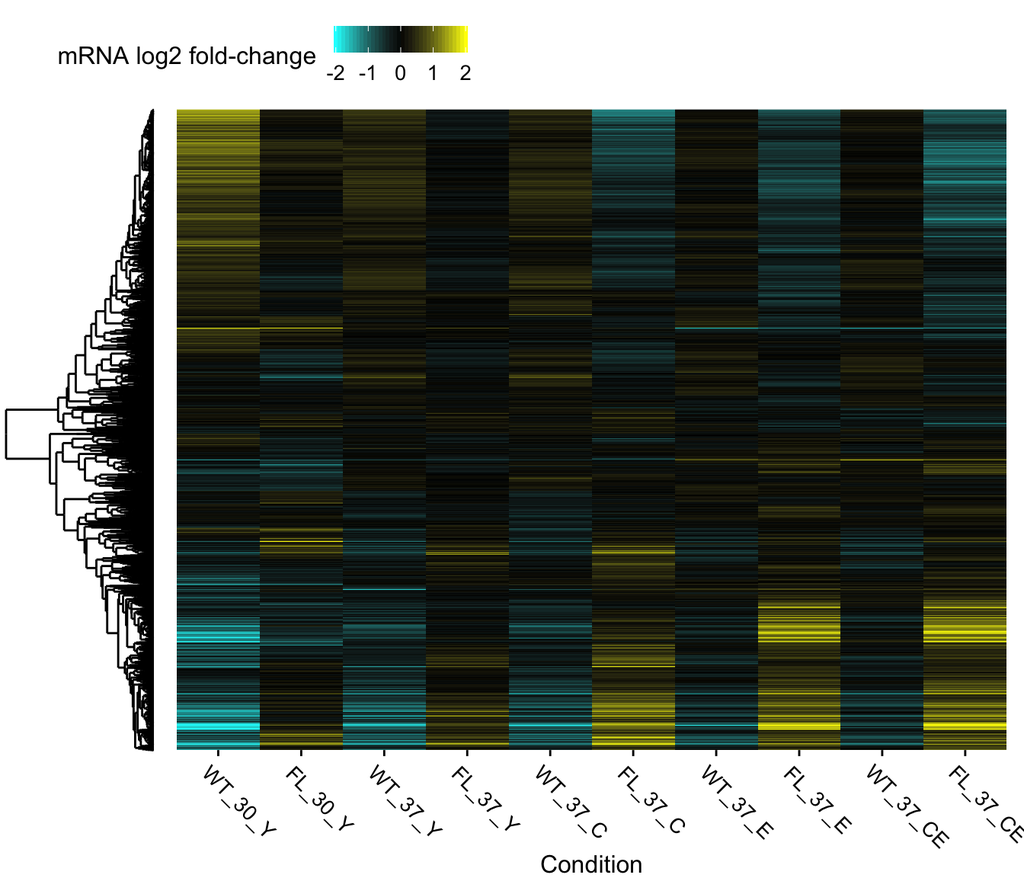

```r
plot_dh_nolegend <-
  plot_grid(plot_dendrogram_log2FC_m10 +
              theme(plot.margin = unit(c(0, 0, 0, 0), "cm")),
          plot_log2FC_m10_dorder +
            theme(axis.title.y = element_blank(),
                  legend.position = "none",
                  plot.margin = unit(c(0, 0.3, 0, 0), "cm")),
          ncol = 2,
          align = "hv",
          rel_widths = c(1,5)
          )

plot_grid(
  get_plot_component(
    plot_log2FC_m10_dorder +
      labs(fill = "mRNA log2 fold-change") +
      theme(legend.box.margin = margin(0, 0, 0, 2, unit = "cm"),
            legend.position = "top"),
    'guide-box-top', return_all = TRUE),
  plot_dh_nolegend,
  ncol = 1,
  rel_heights = c(1,7))
```

```r
ggsave(filename = "../results/clustered_heatmap_Condition.png", width = 6, height = 6)
```